# Why is Zig so Cool?

*by Nilo Stolte*

## Foreword

I can’t think of any other language in my 45 years long career that surprised more than **Zig**. I can easily say that Zig is not only a new programming language, but it’s a totally new way to write programs, in my opinion. To say it’s merely a language to replace C or C++, it’s a huge understatement.

In this article, I will present the features that I found to be most seductive in the language, and I will also present a brief overview about it. The goal is to present **simple** features for programmers to quick start in the language. Be aware, though, that many more features are affecting its acceptability in the industry.

## The compiler

### It compiles C and it cross compiles

Probably the most incredible virtue of Zig compiler is its ability to compile C code. This associated with the ability to cross-compile code to be run in another architecture, different than the machine where it is was originally compiled, is already something quite different and unique. These features alone, completely **out-of-the-box**, are causing an incredible impact in the industry already. In spite of that what we want to concentrate on is how to program in Zig and why should one choose Zig instead of any other language.

### Installing the compiler

Installing the compiler is quite simple. In [Zinglang’s download page](https://ziglang.org/download/) one finds the compiler in several formats, depending on the processor or OS:

[figure not shown]

On **Windows 10**, for example, one chooses the **x86_64** zip file and copy its decompressed content in the desired directory. For example, in “Program Files”. I modified the root directory name to “zig-windows-x86_64” because in this way I can just copy another version of the compiler with no need to modify the path in **Path** environment variable.

Next, one adds this root directory path to the **Path** environment variable using Advanced System Properties (clicking on 1-4, pasting path on 5, and clicking “OK” on 6-8):

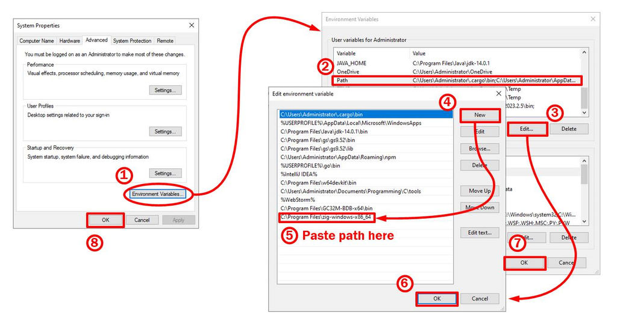

Notice that after setting the path to Zig’s root directory one can already use the compiler in CLI mode. That’s the recommended way to use it for the sake of simplicity.

### Building a “Hello World!” program in Zig

It’s recommended to build a “Hello World!” program using the instructions in the “Getting Started” section in this [site](https://zig.guide/). An alternative installation procedure is also presented there, including for MacOS and Linux (“Installing manually” is highly recommended). It’s also recommended to check the “Language” Basis [section](https://zig.guide/language-basics/assignment), for a deeper insight of Zig language.

## Main concepts and commands

The following sections will give a bird’s eye view of Zig language. Their goal is to instruct the programmer how to quickly start programming in Zig by just knowing a few basic concepts and commands.

Then, a compact view on how to build programs and test modules is given.

Finally, a deeper view on how low level programming can be done in Zig. A more detailed explanation on the examples used is also given.

### Variable declaration

Normally, variable declarations in Zig have potentially three parts. The first part contains the accessibility (`pub` or nothing), followed by the word `var` or `const`, followed by the variable name. The second part, separated of the first part by a colon, contains the variable type declaration. The third part is the initialization of the variable. Only the first and third part are compulsory in Zig, which is kind of puzzling, coming from Java or C. One may wonder how the compiler discovers the variable type. The type in this case is **inferred** by the initialization.

```
var sum : usize = 0;         // variable declaration with 3 parts
```

Variables that don’t have their accessibility explicitly `pub` are local to the module, that is, they aren’t accessible outside the source file it was declared (just like `static` variables in C). It’s not recommended to have variables declared `pub` and it’s recommended to have just few functions declared `pub` in a module to discourage coupling and encourage cohesion. The `pub` functions behave as the module’s API.

### Structs, anonymous structs and test block

In Zig, a `.{` closed with a `}` is an *“anonymous struct literal”* - an anonymous struct mostly used to initialize the elements of another structure or to create a new structure with its elements initialized. A `.{ }` is an an empty anonymous struct literal. The word `struct` followed by a `{` and closed with a `}` is a struct declaration. One can initialize a variable with a type, which functions as an alias to the type. Notice the *“test block”* allowing to compile and execute tests without the need of an executable.

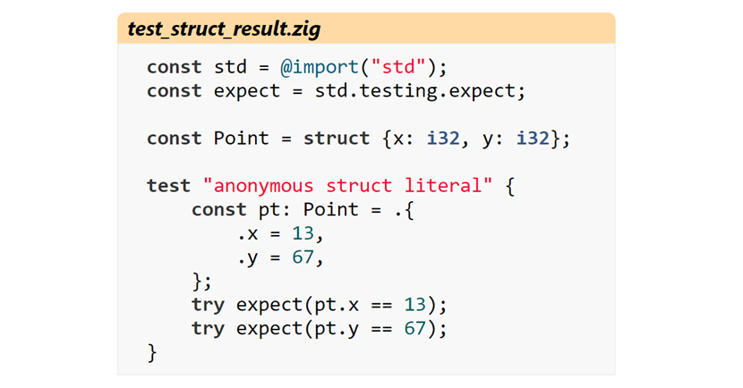

### Bitfields

Bitfields are declared fields with types having specific sizes in a `packed struct`. Pointers can point to a specific bit field as shown here:

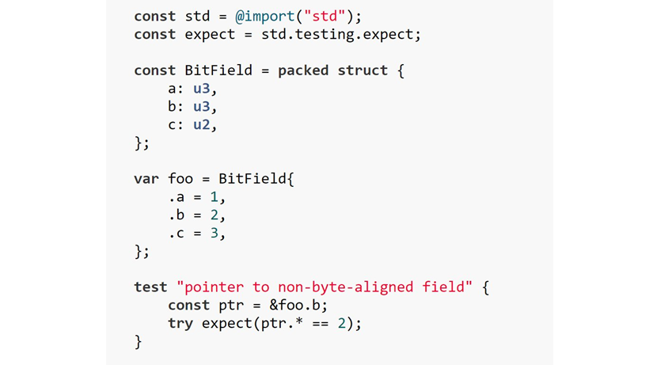

### For loops

Zig syntax is clearer than C’s, except that one would think it should be `[0..8]`, but in reality it’s an open interval: `[0..9)`. **Advantage in Zig**: the type declaration of `i`, its initialization, test, and incrementation are automatic.

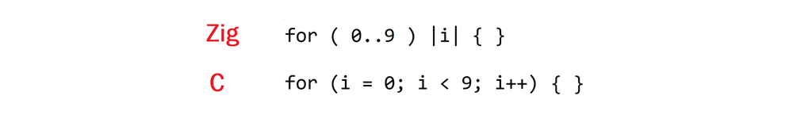

### Arrays

A `[_]` defines an array with unknown size. It must be followed by the type of its elements (here `u8`, *unsigned byte*) and its initialization between `{` and `}`. In this example below, the initialization is saying that this is an array of unknown size (`[_]`) where each element is of type `u8` (unsigned byte) and each element initialized with zeros (`{0} ** 81`). Notice that the size is also inferred by the repetition factor (`81`) of the initialization (`{0}`).

```
var grid = [_]u8{0} ** 81;
```

We see in the figure below a test environment with a loop interacting over the array and adding its elements. The `try expect` statement verifies that `sum` is correct.

The word `byte` is not a type or reserved word in Zig. Here, it’s a variable to hold each of the array’s elements on each step of the loop. Notice that a variable declared between two `|` with an array between the parenthesis of a for loop is always assumed of the same type as the array elements.

Notice also, that `usize` is the natural unsigned integer for the platform. That means on 64 bits machines it’s an `u64`, and in 32 bits machines it’s an `u32`.

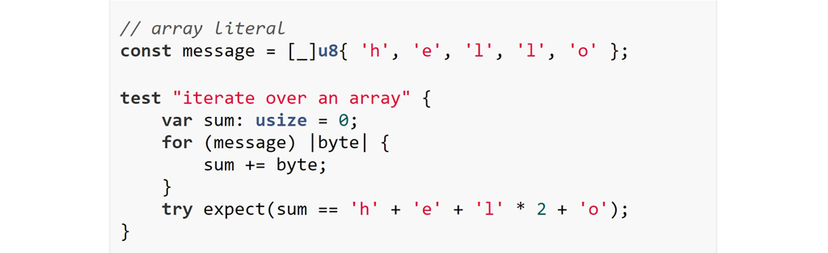

### Many-item pointers in Zig

Pointers to arrays can use pointer arithmetic only if the pointer is *explicitly* declared as a many-item pointer, here `[*]const i32`. Notice that the array below is `const`, can’t be changed, but that the pointer is `var`.

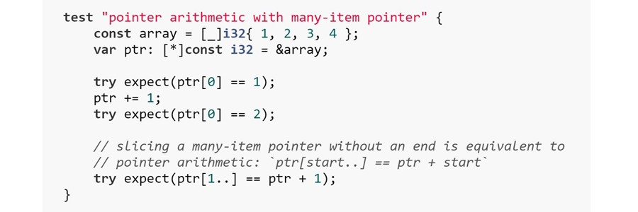

### Dereferencing Pointers

When attributed the address of an individual array position, a pointer cannot be updated with pointer arithmetic. In this case, `const` only prevents its value to be changed with another direct address attribution. To dereference pointers in Zig one uses the `ptr.*` as shown below:

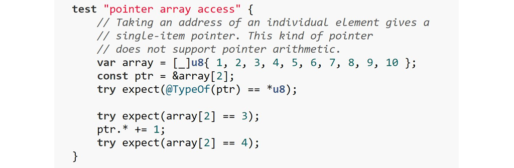

### Labeled breaks

Zig can do many things in compilation time. Let’s initialize an array, for example. Here, a *labelled break* is used. The block is labelled with an `:` after its name `init` and then a value is returned from the block with `break`.

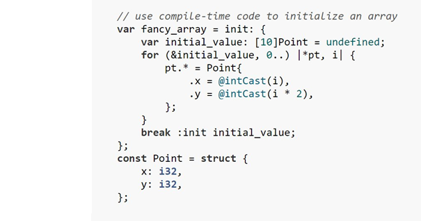

This syntax may look overwhelming. `0..` means an infinite range starting with zero. In the `for`, variables `pt` and `i` are respectively initialized with the address of `initial_value` array and zero. During the loop both are incremented automatically and the loop stops right after dealing with the array’s last position. Also notice how to dereference the `pt` pointer: `pt.*`.

Also interesting it’s how the array is declared in the labelled block. The array is called `initial_value` and has 10 positions of the type `Point` (declared afterwards). Variables must be initialized in Zig. The way to explicitly not initialize is with the reserved word `undefined`.

### Functions in Zig

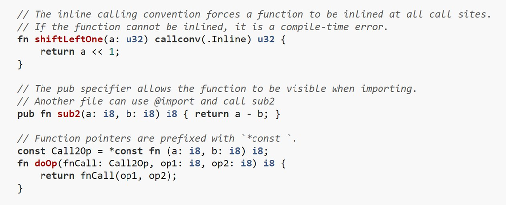

### OOP in Zig

Structs can have functions. Here, a simple stack is implemented. This stack is declared and used only inside the module it is defined, and it accesses and modifies other data structures in the module that are irrelevant in this example. The stack can have at maximum 81 elements (as seen in `stk` declaration), each one of type `StkNode`. Notice that ++ and –– operators don’t exist in Zig. The equivalent += and –= should be used instead. The stack pointer is just an integer used as an index in the `stk` array.

Notice that the pointer `self` (`self` is not a reserved word, but it’s just a convention) is not passed explicitly as a parameter as one would normally expect. It is indirectly assumed that it is a pointer to the instance of the stack the function is been called from. In the example below, a stack pop would be called with `stack.pop();`. In this case the pointer `self` corresponds to a pointer to `stack`. This pointer is then somewhat equivalent to `this` in Java or C++.

Function `init()` is the stack constructor.

Notice as well that functions `pop` and `push` are “inlined.”

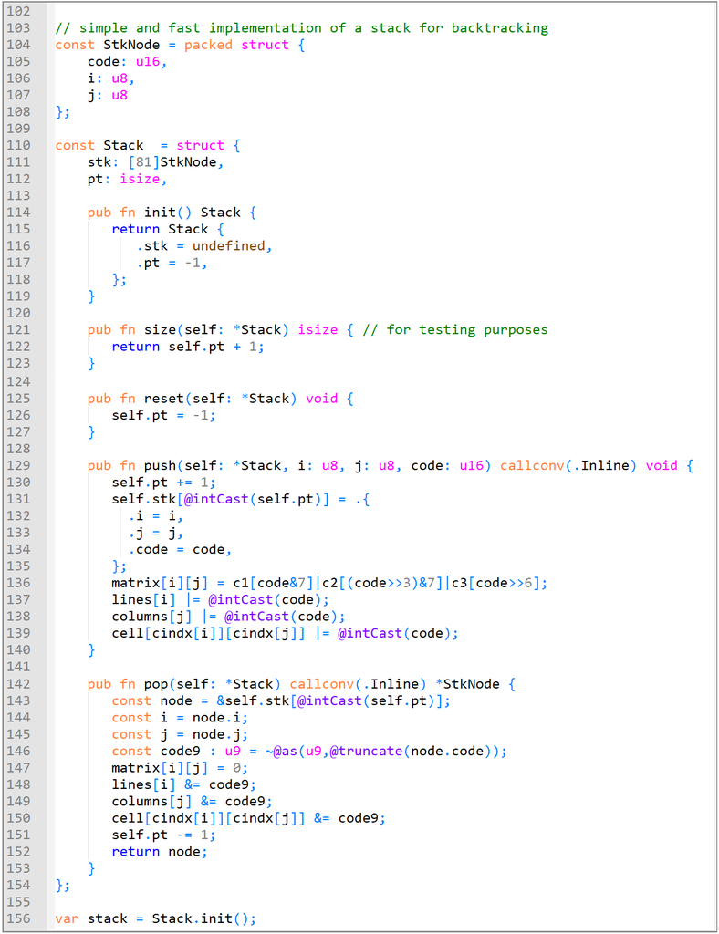

## Building and executing Zig programs

### Building an executable

To build an executable program one needs a `main` function, which indicates the program entry point as in Java or C programs. When this function exists the set of modules can be compiled to an executable code. A simple program can have a `main` function in the same file as the rest of the program. In many cases one can also insert a main function at the end of a module to create an executable in order to debug the module independently. Once debugged this function can be commented out.

In these situations one can use the following command line to compile `program.zig` and to generate an executable program (on Windows, a `program.exe`):

```
zig build-exe -O ReleaseFast program.zig
```

This can be put inside a batch file to prevent typos.

### Executing test blocks in a module

This is probably the best feature of Zig as a programming language. This environment is normally used for testing, but it can also be used for prototyping.

A block in Zig is similar to a block in C or Java, that is, some code between `{` and `}`. A *test block* is a block that starts with `test "message" {` and finishes with `}`, where `"message"` is a string containing the message to be displayed when the test is executed (in this case only the word *message*).

Test blocks are executed independently from an executable file. The final executable file does not execute the tests. The test blocks in a given `module.zig` are compiled together with the entire code in that file and executed by the following command:

```
zig test module.zig
```

##### Example

As a real life example, the *test block* from module example.zig is shown below:

```
test " => testing set and print functions" {
    set(
      "800000000003600000070090200" ++
      "050007000000045700000100030" ++
      "001000068008500010090000400"
    );
    std.debug.print("\n" ++
      "===================\n" ++
      "Input Grid\n" ++
      "===================\n",
      .{}
    );
    print();
}
```

Notice that `example.zig` alone has no *main* function and, therefore, cannot generate an executable, but its test block can be executed by using the following command:

```
zig test example.zig
```

As the message says, the test block above tests the functions `set` and `print`. As the code shows, `set` passes a string of decimal digits as a parameter, followed by a print statement (which prints a header saying “Input Grid” ), followed itself by a call of the `print` function.

The real display in a command tool is the following:

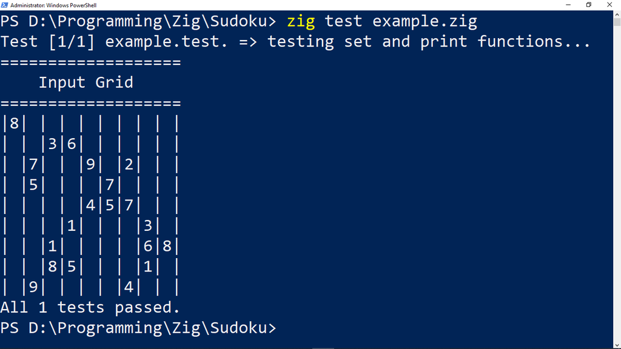

##### Printing in Zig

Let’s focus now on the `std.debug.print` statement. This statement is in fact a call to the function `print` in `debug.zig` in the standard Zig library `std`. The first parameter is a format string, and the second is an *anonymous struct* (preceded by a dot) containing a list of variables to be displayed using the format string. Since there is no formatting in the format string, the struct is empty. This is how formatted prints are done. This one will display in the *stderr* by default, as shown above.

This all looks just like in C language, but there is a fundamental difference here. In C, the *printf* function dynamically interprets the format string in execution time, whereas in Zig it’s possible to deal with the literal string and the list of variables in compilation time. This is a difficult principle to grasp at the start. Many things can be *executed* in compilation time.

### Debugging an executable

Using a debugger is not usually a straightforward task, except in IDEs that already integrate a debugger (as in Java IDEs such as Eclipse or Intellij IDEA) or in integrated development kits (such as w64devkit for C/C++).

A huge inconvenient in using debuggers in this way is that one must integrate the symbols, which not only bloats the code with information that is not useful to the program, but also requires compiling in Debug mode, which generates executable code that’s notoriously less efficient. Someone with practice in complex systems knows that it can be a very time consuming task.

Zig offers a quite convenient hack in order to avoid these headaches.

##### The @breakpoint built-in

This built-in stops a program at the point where a `@breakpoint();` is inserted in the source code when its executable is run in a debugger. This is actually an useful feature to debug optimized Zig code without the need of symbols.

All it’s needed is to trace the variables one wants to watch using `std.debug.print` right before `@breakpoint();` In this way one can know what are the values of the variables at that exact moment.

##### Example

As a real life example, one generates an executable for module debug_example.zig which has the has the following `main` function:

```
pub fn main() !void {
    set(
      "800000000003600000070090200" ++
      "050007000000045700000100030" ++
      "001000068008500010090000400"
    );
}
```

To be able to double check with the results from example.zig, the parameter passed to `set` function in this `main` is the same string as the one passed to `set` in the test block in example.zig, but this time one inserts the following code inside `set` function:

```
        if (c != 0) {
           print();
           std.debug.print(
              "Current digit {}\nposition in string {}\n" ++
              "line {}\ncolumn {}\ncode {b}\n",
              .{c, k, i, j, code}
           );
           @breakpoint();
        }
```

One can then generate the `debug_example.exe` executable with the following build command:

`zig build-exe debug_example.zig`

Next, one uses a debugger to call `debug_example.exe`. In this case I used `gdb`, a debugger for C/C++ included in w64devkit, but it could be any debugger for executable programs. Once inside `gdb`, one needs to run the program using an `r` command and typing `Enter` right after as shown below. Notice that the program printed the grid with its contents so far as well as the variables, stopping at the point expected. Then, by typing `c` command followed by an `Enter` one continues tracing the grid contents and the variables. After that, one can continue by just typing `Enter` (it repeats the last command - `c`, in this case). By continuing typing `Enter` until the program finishes, the values found in the grid correspond to the values shown by the test block in `example.zig` above, since both examples have the same parameter passed to `set`.

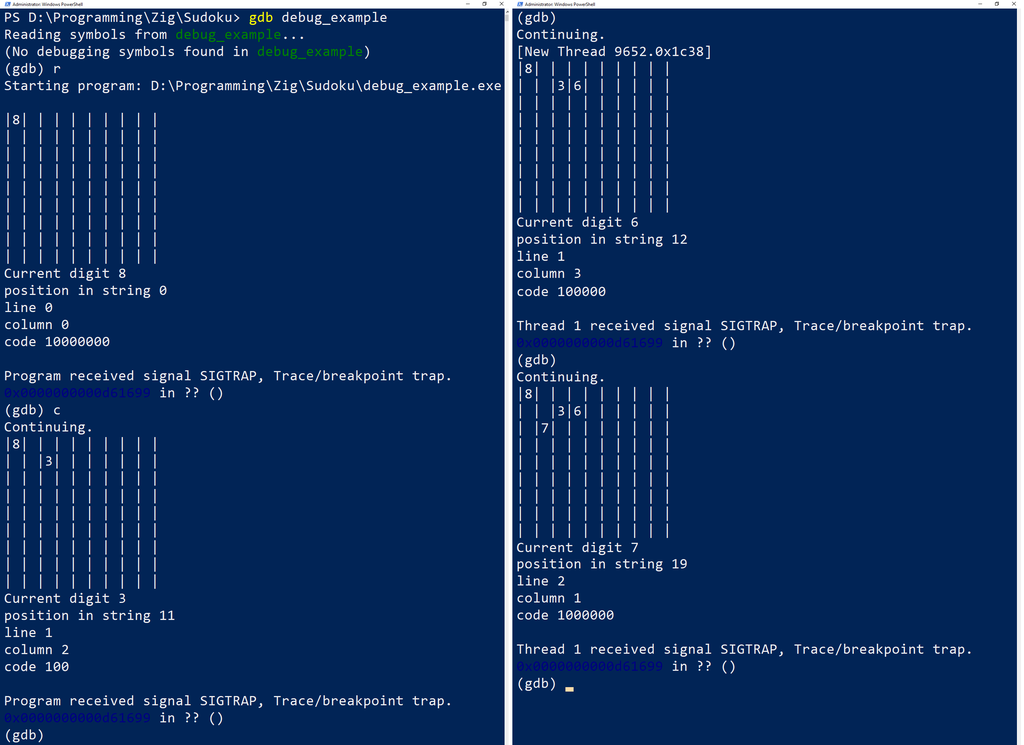

## Low level programming in Zig

With the introduction and the examples given in the previous sections, one can already start programming Zig for writing generic applications. For more advanced programmers, what follows is a more in-depth analysis of some interesting low-level features already used in the examples, but not yet explicitly commented.

The idea of the examples shown is to construct a module that sets (initializes) and displays a 9x9 matrix. This matrix will hold a Sudoku grid, that is, it will only contain elements with decimal digits. The initialization of the grid should guarantee that the grid satisfies the rules of Sudoku game, so it will contain no errors.

At the same time it would be also an excellent opportunity to demonstrate Zig’s low level capabilities, at least the most noticeable ones, and these examples fit this goal quite well.

The whole hypothesis behind these examples is the representation of a grid digit as a bit in the position given by its value. This representation is quite convenient to detect if a digit is already present in the grid or not (these are basic rules of Sudoku grids). In spite of that, this is so encrypted it is only used internally in the module.

### Representing a matrix

With the purpose of having values that are easily understood by humans, the digits are actually stored in the matrix as standard `u8` integers. Even though the input grid in the examples is given in string format, the ASCII characters are internally converted to `u8` integers. The digits’ storage in the grid is organized linearly, line by line, in an array with 81 positions, called `grid` in the examples:

```
var grid = [_]u8{0} ** 81;        // Sudoku grid stored linearly
```

To verify grid correctness, one needs to access the elements by its respective line and column. In other words, one needs to access the elements as in a matrix. The strategy is to create an array of pointers with 9 positions, each one pointing to the start of each line. Blocks of code cannot in principle return a value, but in Zig they can with labeled breaks:

```
const matrix = fill9x9: {         // matrix array to allow access
   var m : [9][*]u8 = undefined;  // to grid element as a matrix,
   var pt : [*]u8 = &grid;        // thus: element = matrix[i][j]
   for (0..9) |i| {               //
      m[i] = pt;                  // stores pointers of each line
      pt += 9;                    // at each position of matrix
   }                              //
   break :fill9x9 m;              // initializes matrix with m
};
```

At the end of the loop, `m` is returned outside the block using a `break :fill9x9 m;` command. Notice that `fill9x9` corresponds to the name of a label placed right before the beginning of the block.

Supposing `i` and `j`, respectively an element’s line and column, any element of the grid can be accessed using this notation:

```
element = matrix[i][j]
```

### Representing decimal digits as bits

The key concept used here is the replacement of an integer decimal digit `i` by an integer `code` such as:

```
      i ∈ [1,9]  →  code = 2ⁱ⁻¹
      i = 0      →  code = 0
```

In other words, the only bit of `code` that is set to `1` is the bit at the position `i-1` if `i` is between `1` and `9`, otherwise all bits of `code` are zero.

##### Values of `code` for each digit

The table below shows the correspondence between digits and their binary representation:

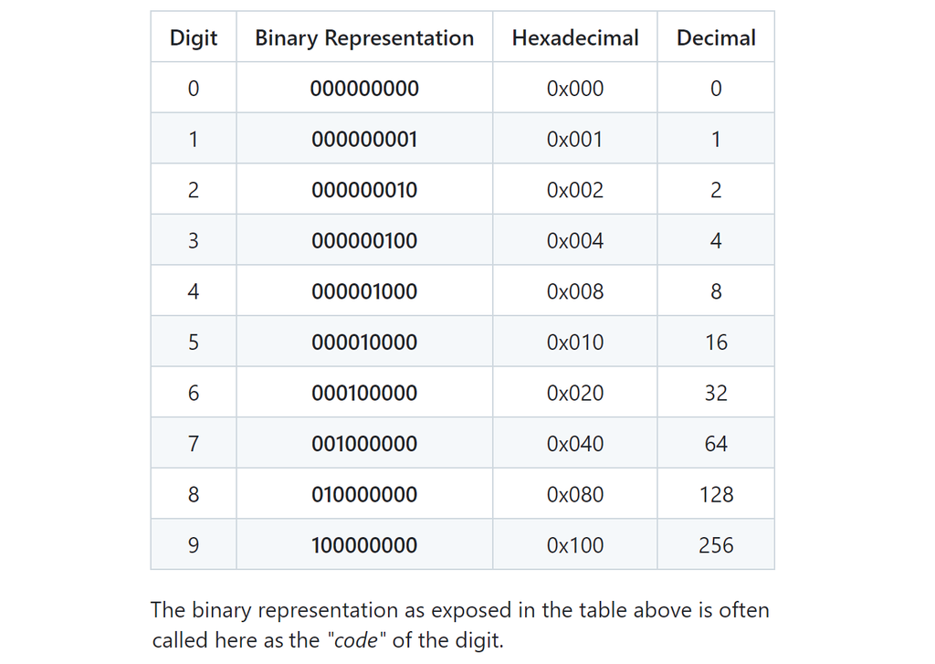

##### Calculating `code` in Zig

The value of `code` is calculated in the function `set` using a left shift operator only if `c` is not zero:

```
code = @as(u9,1) << (c-1);
```

In Zig, constants must have a proper size in order to allow an operation to be compiled and to attribute the the result of an operation to a given variable. In this case, `code` is declared of type `u9`. That’s another fundamental quality of Zig, to be able to have variables with **arbitrary bit size**. As can be seen in the table above, the maximum value that `code` can have is 256, which requires at least 9 bits to represent. The built-in `@as` allows to cast the `1` constant to type `u9`.

### Representing the grid using bitfields

By representing digits as bits one can mirror the entire grid in much simpler ways.

##### Line by line bitfield grid

The array `lines` mirrors the entire grid by representing each line with a `9` bits integer, each bit representing a decimal digit that might be present in the a line:

```
var   lines   = [_]u9{0} ** 9;
```

In this way, by just accessing this array with the line `i` of an element in the 9x9 grid one can know if a given digit is already present in that line, by just performing a bitwise **and** ( `&` ) with the digit’s `code`, in this way:

```
lines[i] & code
```

If the result of the operation above is zero, this means the digit is not yet present in the line `i`. Otherwise we have a duplicate.

##### Column by column bitfield grid

The array `columns` mirrors the entire grid by representing each column with a `9` bits integer:

```
var   columns = [_]u9{0} ** 9;
```

In this way, by just accessing this array with the column `j` of an element in the 9x9 grid one can know if a given digit is already present in that column, by just performing a bitwise **and** ( `&` ) with the digit’s `code`, in this way:

```
columns[i] & code
```

If the result of the operation above is zero, this means the digit is not yet present in the column `j` . Otherwise it’s a duplicate.

##### Sudoku rules

Let’s suppose an empty Sudoku grid, as it is the case when one is populating the grid with the input string as done in the examples. A new digit inserted at any empty element, must not already exist in the entire line, column or cell containing the new element.

Let’s suppose now this grid, already initialized:

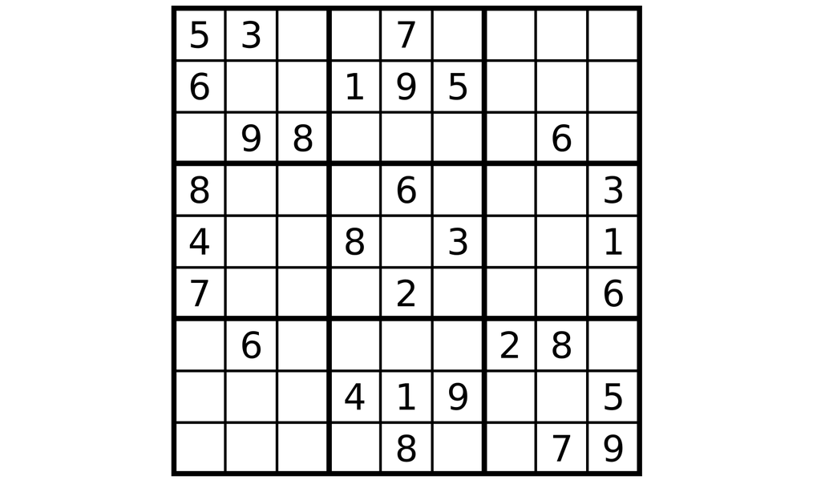

A *cell* is each one of the nine 3x3 grids delimited by the thick lines. The key knowledge to understand at this point is that each specific element in the 9x9 grid has a unique line, column and cell that contains this element.

For example, the first cell of the grid contains the values: 3, 5, 6, 8, and 9. Therefore, the values: 1, 2, 4 and 7 are missing. Let’s suppose one is willing to place the value 7 in one of the empty places in the first cell. Obviously, one cannot place it in the only empty element of the first line, because 7 is already present in that line. One cannot place it in the only empty place in the first column either since 7 is already in that column. One can only place the 7 in one of the two empty elements of the second line. But one can’t know for sure which one is the good one.

Let’s examine now the second cell, which contains the values: 1, 5, 7, and 9. One can see that the only possible element in this cell where an 8 can be placed is in the first line at the empty position on the right of the value 7.

Arrays `lines` and `columns` take care of checking duplicates in lines and in columns. A new array is then needed to check duplicates in cells.

##### Cell by cell bitfield grid

The array `cells` mirrors the entire grid by representing each cell with a `9` bits integer:

```
var   cells   = [_]u9{0} ** 9;    // all elements at each cell
```

Here is where things get more complicated. One cannot access `cells` directly using the line or the column. It would be easier if one could access `cells` as a 3x3 matrix. This can be done mimicking what has been done for the 9x9 matrix, that is, filling the array `cell` as follows:

```
const cell = fill3x3: {           // cell array to allows access
   var m : [3][*]u9 = undefined;  // cell elements as a matrix,
   var pt : [*]u9 = &cells;       // cell[cindx[i]][cindx[j]]
   for (0..3) |i| {               //
      m[i] = pt;                  // stores pointers of each line
      pt += 3;                    // at each position of cell
   }                              //
   break :fill3x3 m;              // initializes cell with m
};                                //
```

But now one needs to determine the line and column in `cell` matrix from the line and column of the element in the original 9x9 grid. One could use integer divisions to divide the line and column by 3 to obtain the proper indexes, but a division operation is notoriously slow. Two divisions makes it even worse. One can use the following array to give the result of the division as follows:

```
const cindx   = [_]usize{ 0,0,0, 1,1,1, 2,2,2 };
```

In this way, by just accessing this matrix with the line `i` and column `j` of an element in the 9x9 grid, one can know if a given digit is already present in this element’s cell by just performing a bitwise **and** ( `&` ) with the digit’s `code`, in this way:

```
cell[cindx[i]][cindx[j]] & code
```

If the result of the operation above is zero, this means the digit is not yet present in the cell. Otherwise it’s a duplicate.

### Testing if an element is duplicated

The complete test to verify if an element is duplicated can be done by composing with a bitwise **or** ( `|` ) all the previous elements in the same line, column and cell, and then performing a bitwise **and** ( `&` ) with the element’s `code`, in this way:

```
if (((lines[i]|columns[j]|cell[cindx[i]][cindx[j]])&code) !=  0) {
    unreachable;
}
```

If the result is zero it’s because the element doesn’t exist yet in its line, column or cell. If the result is not zero the program stops because it tries to run the instruction `unreacheable`. This is the simplest way to explicitly indicate an execution error in Zig. Notice that the actual code in `set` function also prints the details where the error occurs.

For example, replacing the `'0'` right after the first `'8'` by a `'5'` in the string passed to `set` gives the following error while testing example.zig:

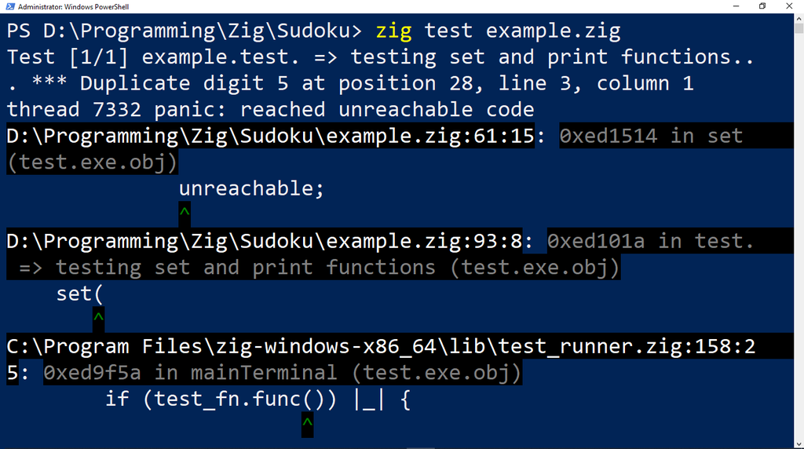

This is because in column 1 there was already a 5 in line 3 as the error message says. The error is due to a panic caused by reaching an unreachable code at function `set` as indicated.

### Updating the data structures

In function `set`, a double `for` loop interacts line by line to copy each new element from the input string `s` into the grid as indicated below (variable `k` keeps the index of the new input character in the string `s`):

```
   for ( 0..9 ) |i| {
      line = matrix[i];
      for ( 0..9 ) |j| {
        c = @intCast(s[k]-'0');
        if (c != 0) {
          code = @as(u9,1) << (c-1);
          ⋮  // rest of the code
        }
        line[j] = c;
        k+= 1;
      }
   }
```

The character is converted to an `u4` (variable `c`) by subtracting `'0'` from it. If the new element to be inserted in the grid is not equal to zero ( `c != 0` ), `code` (calculated with a left shift instruction as indicated) is copied in each of the mirror grids, by doing a bitwise **or** ( `|=` ) with the corresponding mirror grid, that is:

```
    lines[i] |= code;
    columns[j] |= code;
    cell[cindx[i]][cindx[j]] |= code;
```

No test is required to explicitly test if the value of `c` is between `1` and `9` because an overflow will occur at execution time when the shift operation is executed. For example, replacing the `'0'` right after the first `'8'` of the input string by a `':'` in the string passed to `set` gives the following error while testing example.zig:

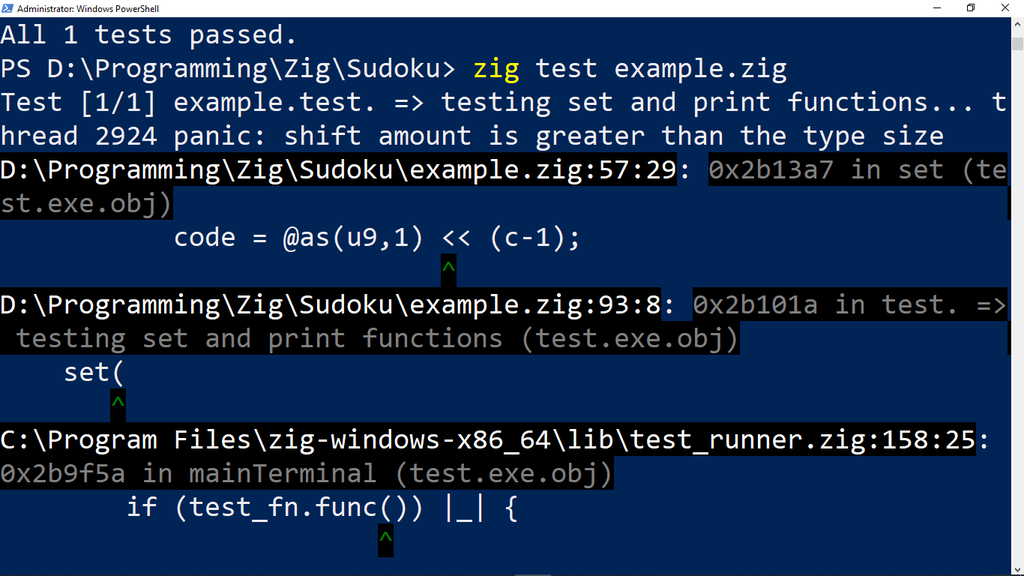

By substituting the same `'0'` by a `'/'` a similar execution error will issued. The program will work only if the values are between `1` and `9`, that is, if the input grid contains only decimal digits.

Many Sudoku grids on the web also represent `'0'` as a `'.'`. That’s the reason the following line exists in `set` function:

```
if (s[k] == '.') c = 0;
```

This will conveniently bypass the shift operation because the value of `c` is zero.

### Prototyping and robustness

The forced errors shown in the two sections above demonstrate important features of Zig that might have passed inconspicuously. One is Zig’s **robustness**. In the case of the shift operation no wrong behavior is allowed and the situation is caught at execution time, as has been shown.

One might think that all the efforts in Zig are towards efficiency, but here it’s a typical case where performance was traded for robustness. One can have mixed feelings about this decision, when performance was the ultimate goal. In C, for example, it’s the programmer’s problem if a shift operation loses a bit and this translates in better performance for this specific Assembler instruction.

Another feature demonstrated in the two sections above is the possibility of using the test blocks for **prototyping** as suggested at the beginning of the article. The possibilities are numerous, even though the application shown was only to debug certain situations in cases of error.

These features alone demonstrate an awesome power, very rare in programming languages, particularly in compiled programing languages.

## Conclusion

Zig resemblance to interpreted languages is quite striking, particularly with its concept of **compile time execution**, unfortunately not stressed enough in this article. This is an aspect of Zig that on one hand makes it particularly different and powerful but on the other hand difficult to grasp.

I concentrated more in instructing how to have a quick and easy start with the language, and in **simple** aspects that make Zig language cool, although there are many other aspects not mentioned here that are also quite impressive.

The examples shown here are simplified versions of a more involved program to [solve Sudoku grids](https://github.com/nilostolte/Sudoku), which was also developed in Java and in C. The documentation in this repository explains in detail most of the structures and algorithms used to accomplish that.